# Supervised Learning - Foundations: ReCell

## Data Preprocessing

- Missing value treatment
- Feature engineering (if needed)
- Outlier detection and treatment (if needed)
- Preparing data for modeling
- Any other preprocessing steps (if needed)

### Missing value treatment

- 'main_camera_mp', 'selfie_camera_mp', 'battery', 'internal memory', and 'weight' have skewed distribution, we will fill the NaN with median.
- 'ram' has quite normal distribution, we will fill the NaN with mean.

```python
# to create a new dataframe from df so we would not make changes on the df file.
df1 = df.copy()
df1["main_camera_mp"].fillna(
    df1.main_camera_mp.median(), inplace=True
)  # to replace NaN with median
df1["selfie_camera_mp"].fillna(
    df1.selfie_camera_mp.median(), inplace=True
)  # to replace rows with median
df1["int_memory"].fillna(
    df1.int_memory.median(), inplace=True
)  # to replace NaN with median
df1["ram"].fillna(df1.ram.mean(), inplace=True)  # to replace NaN with mean
df1["battery"].fillna(df1.battery.median(), inplace=True)  # to replace NaN with median
df1["weight"].fillna(df1.weight.median(), inplace=True)  # to replace NaN with median
```

```python
df1.isnull().sum()  # to return number of missing row(s)
```

```
brand_name          0
os                  0
screen_size         0
4g                  0
5g                  0
main_camera_mp      0
selfie_camera_mp    0
int_memory          0
ram                 0
battery             0
weight              0
release_year        0
days_used           0
new_price           0
used_price          0
dtype: int64
```

### Feature engineering

From EDA, all, except ram, columns have skewness distributions. We will perfrom log transfromation to rectify thier skewness.

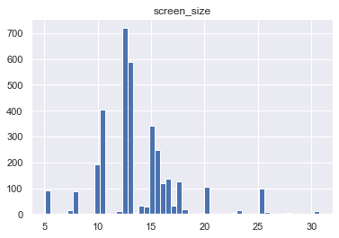

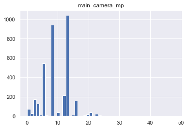

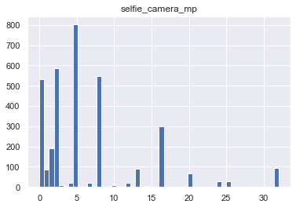

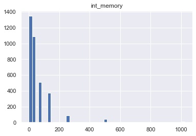

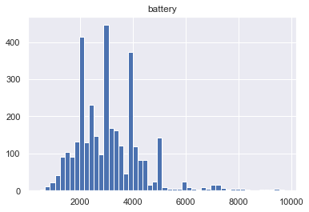

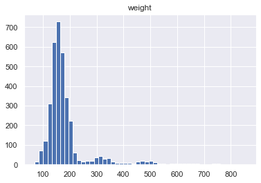

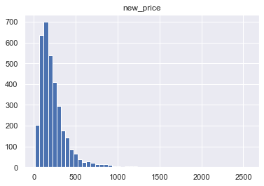

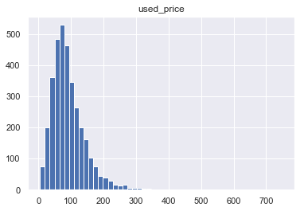

```python
# to create a list and graphs for their distributions
cols_to_log = [
    "screen_size",
    "main_camera_mp",
    "selfie_camera_mp",
    "int_memory",
    "battery",
    "weight",
    "new_price",
    "used_price",
]
for colname in cols_to_log:
    plt.hist(df1[colname], bins=50)
    plt.title(colname)
    plt.show()
# to ghraps columns in cols_to_log
```

```python
# To perfrom log transformation for all columns in cols_to_log in df1 dataframe
for colname in cols_to_log:
    df1[colname + "_log"] = np.log(
        df1[colname] + 1
    )  # +1 to make sure we can perfrom lof transformation for column(s) that has 0 in it.

# to drop cols_to_log to prevent duplications.
df1.drop(
    cols_to_log, axis=1, inplace=True
)  # inplace= True means the dataframe is now updated
```

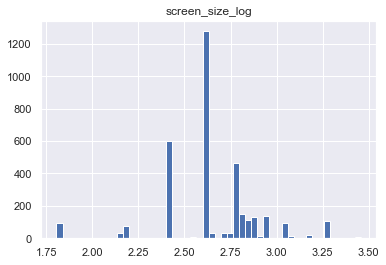

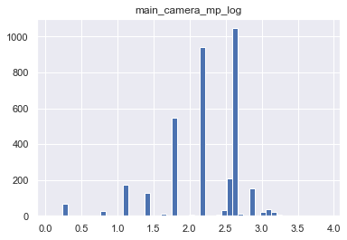

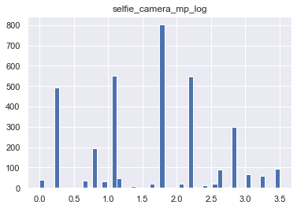

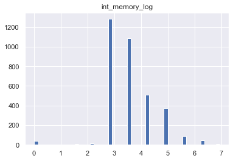

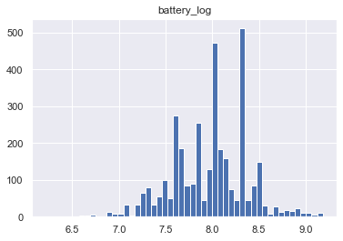

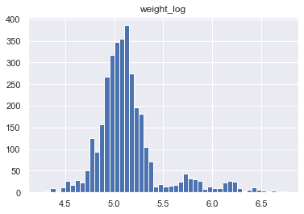

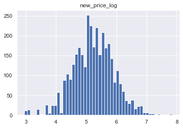

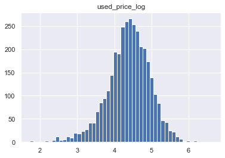

```python
# to create a list that has log transformation
# to create graphs to check their distributions
cols_log = [
    "screen_size_log",
    "main_camera_mp_log",
    "selfie_camera_mp_log",
    "int_memory_log",
    "battery_log",
    "weight_log",
    "new_price_log",
    "used_price_log",
]
for colname in cols_log:
    plt.hist(df1[colname], bins=50)
    plt.title(colname)
    plt.show()
# to graph columns in cols_log
```

- After perfromed the log transformation, new_price and used_price distributions are closed to normal distribution.
- The distributions of screen_size_log, main_camera_mp_log, selfie_camera_mp_log, int_memory_log, and battery_log look slightly better.

### Making categoricals into categorical types

```python
# to create a list
cat_vars = [
    "brand_name",
    "os",
    "4g",
    "5g",
]

for colname in cat_vars:
    df1[colname] = df1[colname].astype("category")

df1.info()  # To check Dtype
```

```
<class 'pandas.core.frame.DataFrame'>
RangeIndex: 3454 entries, 0 to 3453
Data columns (total 15 columns):
 #   Column                Non-Null Count  Dtype
---  ------                --------------  -----
 0   brand_name            3454 non-null   category
 1   os                    3454 non-null   category
 2   4g                    3454 non-null   category
 3   5g                    3454 non-null   category
 4   ram                   3454 non-null   float64
 5   release_year          3454 non-null   int64
 6   days_used             3454 non-null   int64
 7   screen_size_log       3454 non-null   float64
 8   main_camera_mp_log    3454 non-null   float64
 9   selfie_camera_mp_log  3454 non-null   float64
 10  int_memory_log        3454 non-null   float64
 11  battery_log           3454 non-null   float64
 12  weight_log            3454 non-null   float64
 13  new_price_log         3454 non-null   float64
 14  used_price_log        3454 non-null   float64
dtypes: category(4), float64(9), int64(2)
memory usage: 312.2 KB
```

- No object Dtype